# Rice-GWAS-main

Aidan Angus-Henry

```r
library(tidyverse)
library(statgenGWAS)
```

load some data from previous analysis

```r
load("../../Rice-PCA-SNPs/output/data_from_SNP_lab.Rdata")
```

Join the PCs, population assignments, and phenotypes

```r
pheno.geno.pca.pop <- left_join(geno.pca.pop, data.pheno, by=c("ID" = "NSFTVID"))

#get rid of spaces in the phenotype
colnames(pheno.geno.pca.pop) <- make.names(colnames(pheno.geno.pca.pop))

head(pheno.geno.pca.pop)
```

```
## # A tibble: 6 × 56
##   ID       pop1     pop2    pop3   pop4 assignedPop maxPr plot.order   PC1   PC2
##   <chr>   <dbl>    <dbl>   <dbl>  <dbl> <chr>       <dbl>      <int> <dbl> <dbl>
## 1 NSFTV24  1.00 0.000013  1.3e-5 1.3e-5 1            1.00          1 -24.8  5.28
## 2 NSFTV25  1.00 0.000013  1.3e-5 1.4e-5 1            1.00          2 -23.6  6.02
## 3 NSFTV26  1.00 0.000013  1.3e-5 1.3e-5 1            1.00          3 -24.8  5.26
## 4 NSFTV27  1.00 0.000013  1.3e-5 1.4e-5 1            1.00          4 -22.5  4.08
## 5 NSFTV46  1.00 0.000013  1.3e-5 1.4e-5 1            1.00          5 -24.1  4.90
## 6 NSFTV65  1.00 0.000013  1.3e-5 1.4e-5 1            1.00          6 -24.8  5.29
## # … with 46 more variables: PC3 <dbl>, PC4 <dbl>, PC5 <dbl>, PC6 <dbl>,
## #   PC7 <dbl>, PC8 <dbl>, PC9 <dbl>, PC10 <dbl>, Accession_Name <chr>,
## #   Country_of_Origin <chr>, Region <chr>, Alu.Tol <dbl>,
## #   Flowering.time.at.Arkansas <dbl>, Flowering.time.at.Faridpur <dbl>,
## #   Flowering.time.at.Aberdeen <dbl>, FT.ratio.of.Arkansas.Aberdeen <dbl>,
## #   FT.ratio.of.Faridpur.Aberdeen <dbl>, Culm.habit <dbl>,
## #   Leaf.pubescence <dbl>, Flag.leaf.length <dbl>, Flag.leaf.width <dbl>, …
```

Explore a phenotype: I chose `Seed.length`

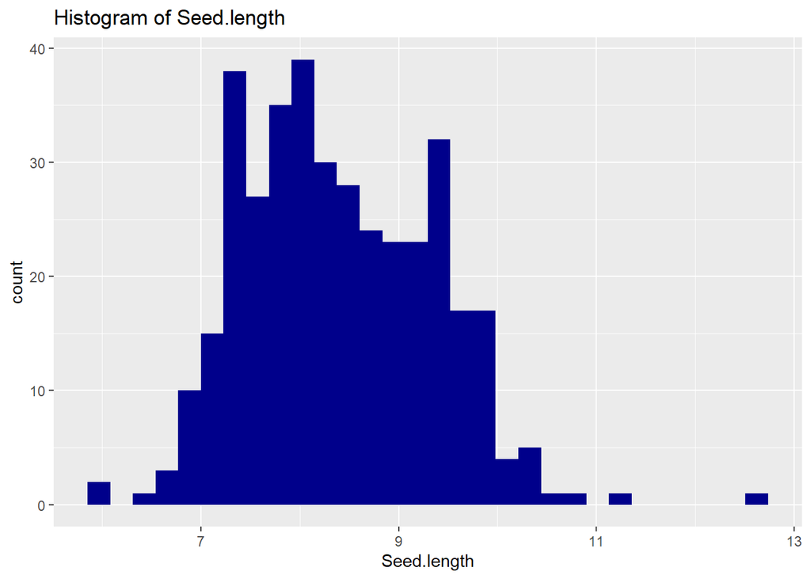

```r
pl <- pheno.geno.pca.pop %>% ggplot(mapping=aes(x=Seed.length))
pl <- pl + labs(title="Histogram of Seed.length")
pl <- pl + geom_histogram(fill="darkblue")
pl
```

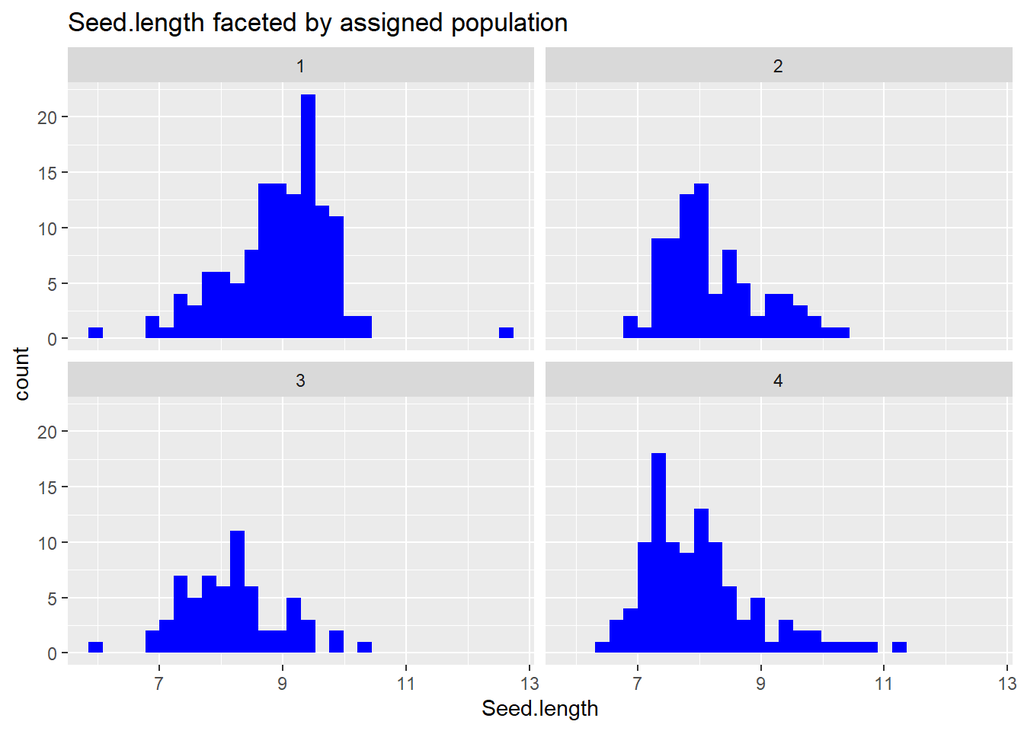

```r
pl2 <- pheno.geno.pca.pop %>% ggplot(mapping=aes(x=Seed.length))
pl2 <- pl2 + labs(title="Seed.length faceted by assigned population")
pl2 <- pl2 + facet_wrap(facets= ~ assignedPop )
pl2 <- pl2 + geom_histogram(fill="blue")
pl2
```

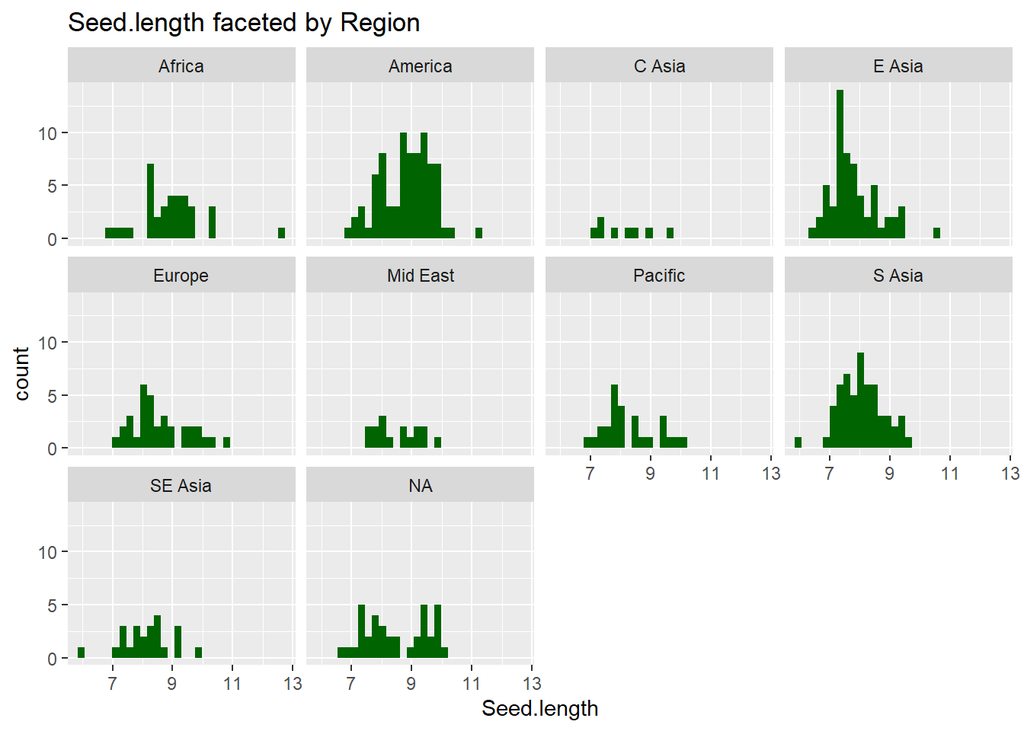

```r
pl3 <- pheno.geno.pca.pop %>% ggplot(mapping=aes(x=Seed.length))
pl3 <- pl3 + labs(title="Seed.length faceted by Region")
pl3 <- pl3 + facet_wrap(facets= ~ Region )
pl3 <- pl3 + geom_histogram(fill="darkgreen")
pl3
```

```r
# Standard error of the mean function
sem <- function(x, na.rm=TRUE) {
  if(na.rm) x <- na.omit(x)
  sd(x)/sqrt(length(x))
}

pheno.geno.pca.pop %>% group_by(Region) %>%
  summarize(mean.seed.l=mean(Seed.length,na.rm=T),
            sem.seed.l=sem(Seed.length)
  ) %>%
  arrange(desc(mean.seed.l))
```

```
## # A tibble: 10 × 3
##    Region   mean.seed.l sem.seed.l
##    <chr>          <dbl>      <dbl>
##  1 Africa          8.95     0.175
##  2 America         8.85     0.0952
##  3 Europe          8.58     0.161
##  4 Mid East        8.54     0.181
##  5 <NA>            8.49     0.173
##  6 Pacific         8.27     0.168
##  7 C Asia          8.12     0.318
##  8 SE Asia         8.11     0.177
##  9 S Asia          8.07     0.0978
## 10 E Asia          7.81     0.104
```

perform an ANOVA to investigate whether or not the differences of the mean seed lengths for different regions are significant.

```r
aovsl <- aov(Seed.length ~ Region, data=pheno.geno.pca.pop)
summary(aovsl)
```

```
##              Df Sum Sq Mean Sq F value   Pr(>F)
## Region        8  58.22   7.278   9.983 1.81e-12 ***
## Residuals   331 241.30   0.729
## ---
## Signif. codes:  0 '***' 0.001 '**' 0.01 '*' 0.05 '.' 0.1 ' ' 1
## 73 observations deleted due to missingness
```

Through the ANOVA above, we can conclude that Seed length varies significantly by region.

Now it would be good to check if mean seed length varies significantly by fastStructure population assignment.

```r
pheno.geno.pca.pop %>% group_by(assignedPop) %>% summarize(mean.Seed.length=mean(Seed.length, na.rm = T), sem.Seed.length=sem(Seed.length)) %>%
 arrange(desc(mean.Seed.length))
```

```
## # A tibble: 4 × 3
##   assignedPop mean.Seed.length sem.Seed.length
##   <chr>                  <dbl>           <dbl>
## 1 1                       8.93          0.0773
## 2 2                       8.23          0.0870
## 3 3                       8.18          0.104
## 4 4                       8.02          0.0930
```

```r
aov2 <- aov(Seed.length ~ assignedPop, data=pheno.geno.pca.pop)
summary(aov2)
```

```
##              Df Sum Sq Mean Sq F value  Pr(>F)
## assignedPop   3  56.97  18.988   25.04 8.8e-15 ***
## Residuals   373 282.84   0.758
## ---
## Signif. codes:  0 '***' 0.001 '**' 0.01 '*' 0.05 '.' 0.1 ' ' 1
## 36 observations deleted due to missingness
```

This analysis reveals that seed length does vary significantly by assigned population, suggesting that population structure could be a problem in a future GWAS

### Time to prepare GWAS data

Load Genotype data

```r
Sys.setenv(VROOM_CONNECTION_SIZE="500000") # needed because the lines in this file are long.

data.geno <- read_csv("../../Rice-PCA-SNPs/input/Rice_44K_genotypes.csv.gz",
                      na=c("NA","00"))  %>%
  rename(ID=`...1`, `6_17160794` = `6_17160794...22252`) %>%
  select(-`6_17160794...22253`)
```

```
## ──────────────────────────────────────────────────────── Delimiter: "," chr
## (36902): ...1, 1_13147, 1_73192, 1_74969, 1_75852, 1_75953, 1_91016, 1_1...
```

Transform ID data into rownames (for statgenGWAS)

```r
data.geno <- data.geno %>% as.data.frame() %>% column_to_rownames("ID")
head(data.geno[,1:10])
```

```
##        1_13147 1_73192 1_74969 1_75852 1_75953 1_91016 1_146625 1_149005
## NSFTV1      TT      TT      CC      GG      TT      AA       CC       TT
## NSFTV3      CC      CC      CC      AA      GG    <NA>       CC       GG
## NSFTV4      CC      CC      CC      AA      GG      GG       CC       GG
## NSFTV5      CC      CC      TT      GG      GG      AA       TT       GG
## NSFTV6      CC      CC      CC      AA      GG      GG       CC       GG
## NSFTV7      TT      TT      CC      GG      TT      AA       CC       TT
##        1_149754 1_151492
## NSFTV1       AA       AA
## NSFTV3       TT       GG
## NSFTV4       TT       GG
## NSFTV5       TT       AA
## NSFTV6       TT       GG
## NSFTV7       AA       AA
```

```r
data.map <- data.frame(SNP=colnames(data.geno)) # create the object
head(data.map)
```

```
##       SNP
## 1 1_13147
## 2 1_73192
## 3 1_74969
## 4 1_75852
## 5 1_75953
## 6 1_91016
```

create the data.map object for GWAS

```r
data.map <- data.map %>%
  separate(SNP, into=c("chr", "pos"), sep="_", remove=FALSE, convert=TRUE ) %>%
  column_to_rownames("SNP")

head(data.map)
```

```
##         chr   pos
## 1_13147   1 13147
## 1_73192   1 73192
## 1_74969   1 74969
## 1_75852   1 75852
## 1_75953   1 75953
## 1_91016   1 91016
```

Create phenotype data

```r
data.pheno.small <- data.pheno %>%
  set_names(make.names(colnames(.))) %>%
  rename(genotype=NSFTVID) %>%
  select(genotype, where(is.numeric)) %>%
  as.data.frame() # for GWAS, need data frames, not tibbles ;()

head(data.pheno.small)
```

```
##   genotype Alu.Tol Flowering.time.at.Arkansas Flowering.time.at.Faridpur
## 1   NSFTV1    0.73                   75.08333                         64
## 2   NSFTV3    0.30                   89.50000                         66
## 3   NSFTV4    0.54                   94.50000                         67
## 4   NSFTV5    0.44                   87.50000                         70
## 5   NSFTV6    0.57                   89.08333                         73
## 6   NSFTV7    0.86                  105.00000                         NA
##   Flowering.time.at.Aberdeen FT.ratio.of.Arkansas.Aberdeen
## 1                         81                     0.9269547
## 2                         83                     1.0783133
## 3                         93                     1.0161290
## 4                        108                     0.8101852
## 5                        101                     0.8820132
## 6                        158                     0.6645570
##   FT.ratio.of.Faridpur.Aberdeen Culm.habit Leaf.pubescence Flag.leaf.length
```

[output cut: 55 more lines]

Lastly, create data frame of covariates

```r
data.cv <- geno.pca.pop %>%
  as.data.frame() %>%
  column_to_rownames("ID")
```

Create the gdata object

```r
gData.rice <- createGData(geno=data.geno, map = data.map, pheno = data.pheno.small, covar = data.cv)
```

Recode the genotype data (will look into SNP imputation in the future)

```r
gData.rice.recode <- gData.rice %>% codeMarkers(verbose = TRUE)
```

```
## Input contains 36900 SNPs for 413 genotypes.
## 0 genotypes removed because proportion of missing values larger than or equal to 1.
## 0 SNPs removed because proportion of missing values larger than or equal to 1.
## 569 duplicate SNPs removed.
## 660509 missing values imputed.
## 442 duplicate SNPs removed after imputation.
## Output contains 35889 SNPs for 413 genotypes.
```

Create a kinship matrix to help correct for pop. structure

```r
data.kinship <- kinship(gData.rice.recode$markers)
```

Now it is time to run the GWAS. This will be done in different ways to compare methods of population structure correction

First, running the GWAS with no correction for pop. structure

```r
#define a zero matrix
nullmat <- matrix(0, ncol=413,nrow=413, dimnames = dimnames(data.kinship))

# run the GWAS
gwas.noCorrection<- runSingleTraitGwas(gData = gData.rice.recode,
                                       traits = "Seed.length",
                                       kin = nullmat)
```

quickly examine results

```r
summary(gwas.noCorrection)
```

```
## data.pheno.small:
##  Traits analysed: Seed.length
##
##  Data are available for 35889 SNPs.
##   79 of them were not analyzed because their minor allele frequency is below 0.01
##
##  GLSMethod: single
##
##  Trait: Seed.length
##
##      Mixed model with only polygenic effects, and no marker effects:
##      Genetic variance: 0.0001541494
##      Residual variance: 0.9037314
##
##      LOD-threshold: 5.855034
##      Number of significant SNPs: 2889
##      Smallest p-value among the significant SNPs: 1.804975e-22
##      Largest p-value among the significant SNPs: 1.387434e-06 (LOD-score: 5.857788)
##
##      No genomic control correction was applied
##      Genomic control inflation-factor: 9.954
```

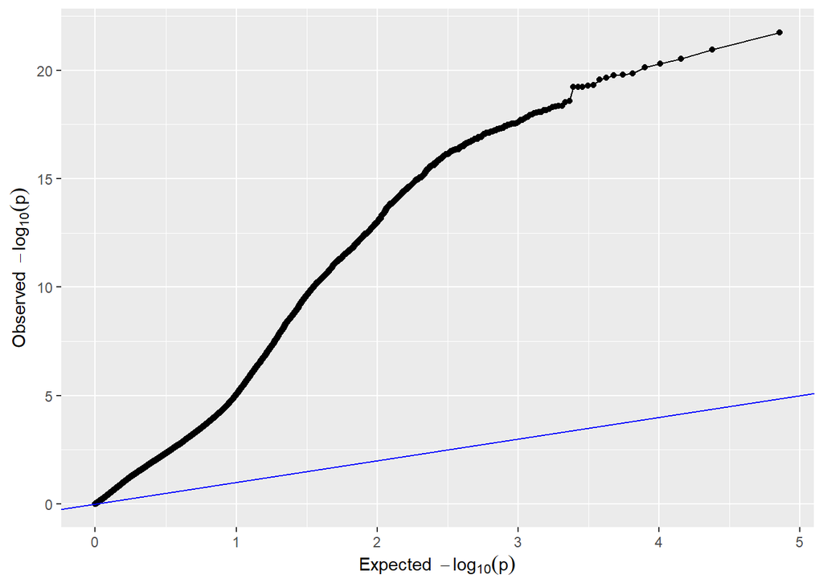

```r
plot(gwas.noCorrection, plotType = "qq") # View qq plot
```

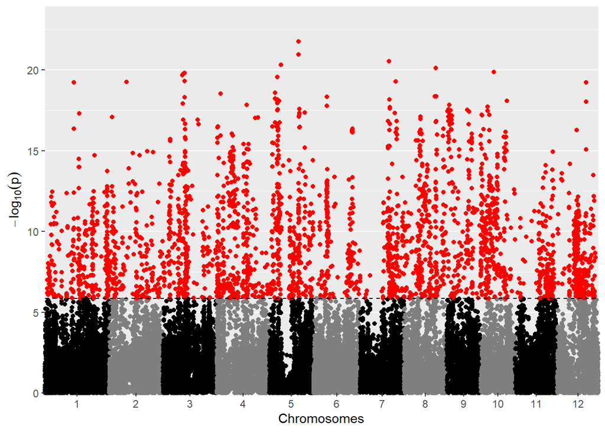

```r
plot(gwas.noCorrection, plotType = "manhattan") # View manhattan plot
```

Run GWAS again, but include PCs for pop. structure correction

```r
gwas.PCA <- runSingleTraitGwas(gData = gData.rice.recode,
                               traits = "Seed.length",
                               kin = nullmat,
                               covar = c("PC1", "PC2", "PC3", "PC4")

)
```

View results

```r
summary(gwas.PCA)
```

```
## data.pheno.small:
##  Traits analysed: Seed.length
##
##  Data are available for 35889 SNPs.
##   79 of them were not analyzed because their minor allele frequency is below 0.01
##
##  GLSMethod: single
##
##  Trait: Seed.length
##
##      Mixed model with only polygenic effects, and no marker effects:
##      Genetic variance: 0.0001150033
##      Residual variance: 0.6742298
##
##      LOD-threshold: 5.855034
##      Number of significant SNPs: 179
##      Smallest p-value among the significant SNPs: 3.400659e-18
##      Largest p-value among the significant SNPs: 1.34804e-06 (LOD-score: 5.870297)
##
##      No genomic control correction was applied
##      Genomic control inflation-factor: 2.643
```

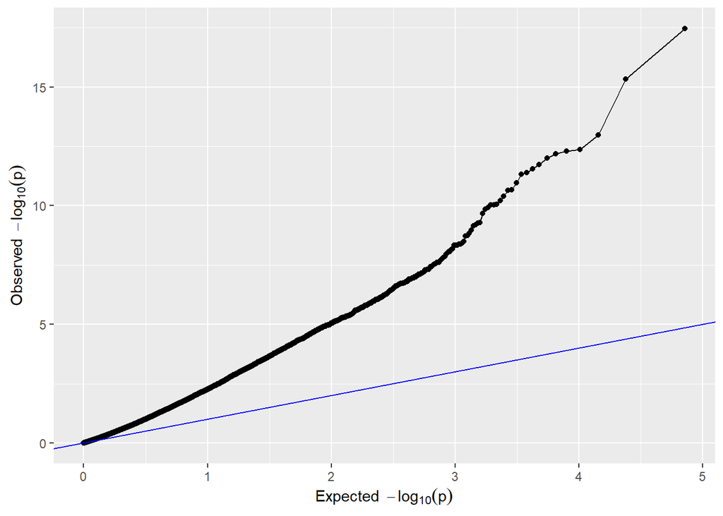

```r
plot(gwas.PCA, plotType = "qq")
```

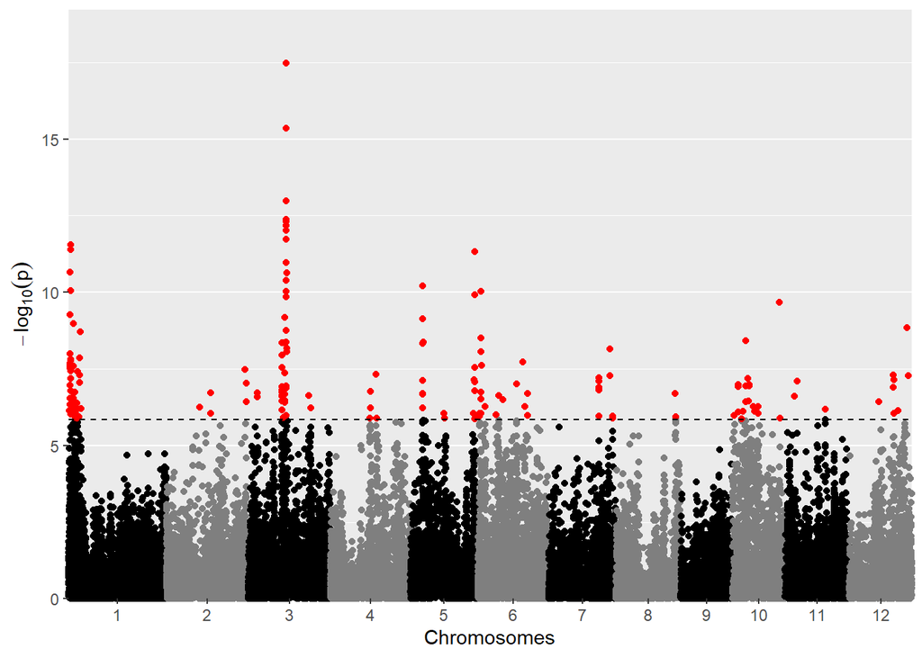

```r
plot(gwas.PCA, plotType = "manhattan")
```

Now, run a GWAS and use a kinship matrix as pop. structure correction

```r
gwas.K <- runSingleTraitGwas(gData = gData.rice.recode,
                             traits = "Seed.length",
                             kin = data.kinship)
```

View the results

```r
summary(gwas.K)
```

```
## data.pheno.small:
##  Traits analysed: Seed.length
##
##  Data are available for 35889 SNPs.
##   79 of them were not analyzed because their minor allele frequency is below 0.01
##
##  GLSMethod: single
##
##  Trait: Seed.length
##
##      Mixed model with only polygenic effects, and no marker effects:
##      Genetic variance: 0.7477485
##      Residual variance: 4.146573e-05
##
##      LOD-threshold: 5.855034
##      Number of significant SNPs: 7
##      Smallest p-value among the significant SNPs: 1.197478e-11
##      Largest p-value among the significant SNPs: 1.17562e-06 (LOD-score: 5.929733)
##
##      No genomic control correction was applied
##      Genomic control inflation-factor: 0.818
```

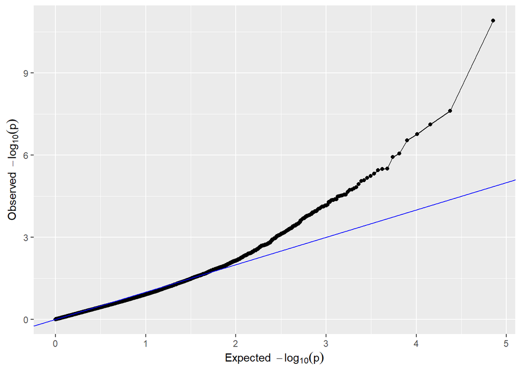

```r
plot(gwas.K, plotType = "qq")
```

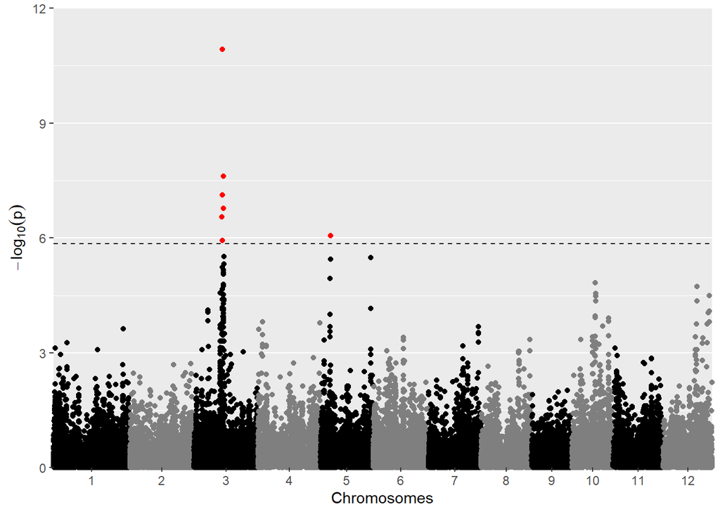

```r
plot(gwas.K, plotType = "manhattan")
```

This GWAS looks like the best one so far (qq plot)

Extract the significant SNPs from the kinship martix corrected GWAS

```r
sigSnps <- gwas.K$signSnp[[1]]
sigSnps
```

```
##          trait        snp chr      pos   allFreq       pValue     effect
## 1: Seed.length 3_15996630   3 15996630 0.3660477 2.857730e-07 -0.3139402
## 2: Seed.length 3_16074273   3 16074273 0.3607427 1.197478e-11 -0.4134219
## 3: Seed.length 3_16172962   3 16172962 0.2307692 7.439578e-08  0.2985353
## 4: Seed.length 3_16267191   3 16267191 0.4907162 1.175620e-06  0.2756402
## 5: Seed.length 3_16706777   3 16706777 0.2559682 2.422682e-08 -0.4544777
## 6: Seed.length 3_16759297   3 16759297 0.2281167 1.701436e-07 -0.4316659
## 7: Seed.length  5_5537790   5  5537790 0.3527851 8.784136e-07 -0.2888504
##      effectSe       RLR2       LOD       snpStatus propSnpVar
## 1: 0.06212069 0.06550164  6.543979 significant SNP 0.10091900
## 2: 0.06272755 0.10883016 10.921733 significant SNP 0.17391192
## 3: 0.05645051 0.07149980  7.128452 significant SNP 0.06968562
## 4: 0.05750127 0.05913174  5.929733 significant SNP 0.08381828
## 5: 0.08299865 0.07645152  7.615704 significant SNP 0.17396504
## 6: 0.08389129 0.06782025  6.769184 significant SNP 0.14012204
## 7: 0.05957589 0.06044966  6.056301 significant SNP 0.08454322
```

Sort significant SNPs by p-value

```r
sigSnps2 <- arrange(sigSnps, pValue)
head(sigSnps2)
```

```
##          trait        snp chr      pos   allFreq       pValue     effect
## 1: Seed.length 3_16074273   3 16074273 0.3607427 1.197478e-11 -0.4134219
## 2: Seed.length 3_16706777   3 16706777 0.2559682 2.422682e-08 -0.4544777
## 3: Seed.length 3_16172962   3 16172962 0.2307692 7.439578e-08  0.2985353
## 4: Seed.length 3_16759297   3 16759297 0.2281167 1.701436e-07 -0.4316659
## 5: Seed.length 3_15996630   3 15996630 0.3660477 2.857730e-07 -0.3139402
## 6: Seed.length  5_5537790   5  5537790 0.3527851 8.784136e-07 -0.2888504
##      effectSe       RLR2       LOD       snpStatus propSnpVar
## 1: 0.06272755 0.10883016 10.921733 significant SNP 0.17391192
## 2: 0.08299865 0.07645152  7.615704 significant SNP 0.17396504
## 3: 0.05645051 0.07149980  7.128452 significant SNP 0.06968562
## 4: 0.08389129 0.06782025  6.769184 significant SNP 0.14012204
## 5: 0.06212069 0.06550164  6.543979 significant SNP 0.10091900
## 6: 0.05957589 0.06044966  6.056301 significant SNP 0.08454322
```